# Homework5-DataVis-ggplot

Masoud A. Rostami

DUE: Thursday, March 10

#### Necessary items:

- **libraries:** tidyverse, ggsci, ggforce, patchwork, Hmisc
- **files:** bloom_df.csv, hw_task2_blank.png

Within RStudio you can directly edit these blocks of code and turn in your homework that way with your code and figures printed.  
I **HIGHLY** recommend getting your code to work in a normal R script then just copy and pasting the final code over to this document

**First: import libraries, set your working directory, and read in bloom_df**

```r
library(tidyverse)
library(ggforce)
library(ggsci)
library(patchwork)
library(Hmisc)
library(ggpubr)

setwd("/Users/masoud/Desktop/Part.4.DataVisualization") #change to match your ggplot directory

bloom_df <- read.csv('bloom_df.csv')
```

### bloom_df contents

- **taxa:** genus_species
- **genus**
- **species**
- **logbodysize**
- **trophic_position**
- **reg:** diadromous or non-diadromous

Let’s take a peak and look at the structure, top rows and name of variables in our dataset.

```r
head(bloom_df)
```

```
##                   taxa genus        species logbodysize trophic_position
## 1       Alosa_alabamae Alosa       alabamae    1.707570        0.4313638
## 2          Alosa_alosa Alosa          alosa    1.778151        0.5563025
## 3         Alosa_fallax Alosa         fallax    1.778151        0.5563025
## 4      Alosa_mediocris Alosa      mediocris    1.778151        0.6127839
## 5 Alosa_pseudoharengus Alosa pseudoharengus    1.602060        0.5440680
## 6    Alosa_sapidissima Alosa    sapidissima    1.790285        0.5440680
##          reg
## 1 diadromous
## 2 diadromous
## 3 diadromous
## 4 diadromous
## 5 diadromous
## 6 diadromous
```

```r
names(bloom_df)
```

```
## [1] "taxa"             "genus"            "species"          "logbodysize"
## [5] "trophic_position" "reg"
```

```r
str(bloom_df)
```

```
## 'data.frame':    50 obs. of  6 variables:
##  $ taxa            : Factor w/ 50 levels "Alosa_alabamae",..: 1 2 3 4 5 6 7 8 9 10 ...
##  $ genus           : Factor w/ 34 levels "Alosa","Amazonsprattus",..: 1 1 1 1 1 1 2 3 3 3 ...
##  $ species         : Factor w/ 48 levels "aestuaria","alabamae",..: 2 3 19 31 36 39 41 11 13 14 ...
##  $ logbodysize     : num  1.71 1.78 1.78 1.78 1.6 ...
##  $ trophic_position: num  0.431 0.556 0.556 0.613 0.544 ...
##  $ reg             : Factor w/ 2 levels "diadromous","non-diadromous": 1 1 1 1 1 1 2 2 2 2 ...
```

### Graphical tasks

This next tasks are going to ask you to make a series of figures. For each one, I would like you to make all of them *look good*. Change the theme around, change the axis labels, etc. Additionally, each of these will use the **reg** column which has 2 factors. Change the color and/or shape of them both.

### Task 1: Continuous vs. continuous plot

Create two scatterplots of logbodysize vs. trophic_position grouped by reg

##### First plot:

- a 2 trend lines (method = ‘lm’), one for each reg variable

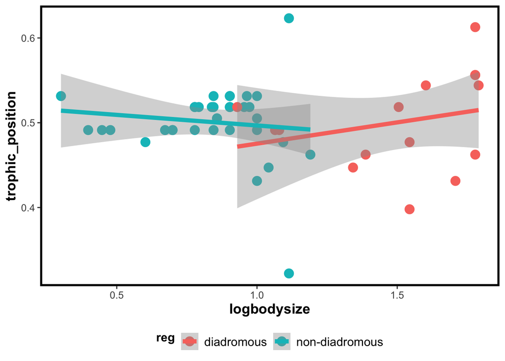

```r
ggplot(bloom_df ,aes(x=logbodysize,y=trophic_position,colour=reg)) +
  geom_point(size=4)+stat_smooth(method="lm", size=2)+theme_bw()+
  theme(legend.position = 'bottom', plot.title = element_text(size = 20, colour="black",face = "bold"),
        axis.text = element_text(size=10),
        axis.title = element_text(size = 14, colour="black",face = "bold"),
        panel.border = element_rect(size = 2, colour = "black"),
        legend.title = element_text(size = 12, colour="black",face = "bold",vjust = 1),
        legend.text = element_text(size=12),
        panel.grid.major = element_blank(), panel.grid.minor = element_blank())
```

##### Second plot

- a single trend line for the whole model

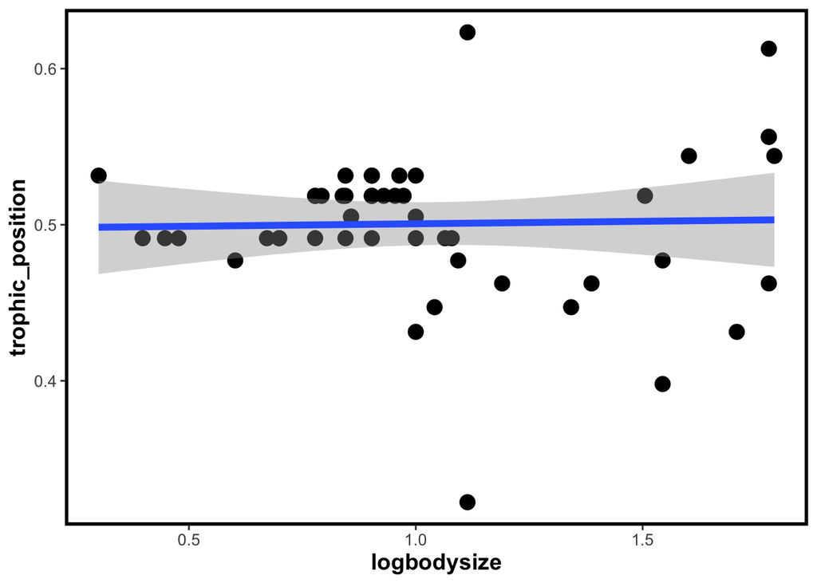

```r
ggplot(bloom_df ,aes(x=logbodysize,y=trophic_position)) +
  geom_point(size=4)+stat_smooth(method="lm", size=2)+theme_bw()+
  theme(legend.position = 'bottom', plot.title = element_text(size = 20, colour="black",face = "bold"),
        axis.text = element_text(size=10),
        axis.title = element_text(size = 14, colour="black",face = "bold"),
        panel.border = element_rect(size = 2, colour = "black"),
        legend.title = element_text(size = 12, colour="black",face = "bold",vjust = 1),
        legend.text = element_text(size=12),
        panel.grid.major = element_blank(), panel.grid.minor = element_blank())
```

### Task 2: Continuous vs. categorical

##### The layout will be:

- 2 panels: trophic_position and logbodysize
- x axis: reg
- y axis: value of trophic_position and logbodysize

##### Create 4 plots:

- bar and error bars (mean and 95% conf. int.)
- point and error bars (mean and 95% conf. int.)
- box plots
- raw data + point and error bars (mean and 95% conf. int.)

All these plots should have the same general layout but change the type of plot to visualize the data.

**HINT:** logbodysize and trophic_position need to be turned into long format

##### Example layout:

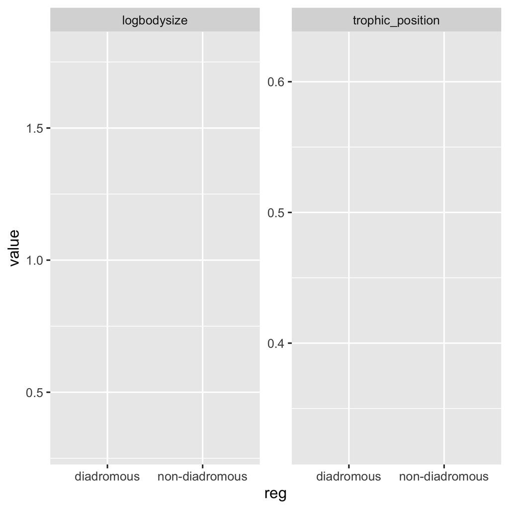

##### Create a long format dataset

```r
Bloom_long_df <- bloom_df %>%
  pivot_longer(cols = c(logbodysize, trophic_position), names_to = "cat", values_to = "value")

head(Bloom_long_df,10)
```

```
## # A tibble: 10 x 6
##    taxa                 genus species        reg        cat              value
##    <fct>                <fct> <fct>          <fct>      <chr>            <dbl>
##  1 Alosa_alabamae       Alosa alabamae       diadromous logbodysize      1.71
##  2 Alosa_alabamae       Alosa alabamae       diadromous trophic_position 0.431
##  3 Alosa_alosa          Alosa alosa          diadromous logbodysize      1.78
##  4 Alosa_alosa          Alosa alosa          diadromous trophic_position 0.556
##  5 Alosa_fallax         Alosa fallax         diadromous logbodysize      1.78
##  6 Alosa_fallax         Alosa fallax         diadromous trophic_position 0.556
##  7 Alosa_mediocris      Alosa mediocris      diadromous logbodysize      1.78
##  8 Alosa_mediocris      Alosa mediocris      diadromous trophic_position 0.613
##  9 Alosa_pseudoharengus Alosa pseudoharengus diadromous logbodysize      1.60
## 10 Alosa_pseudoharengus Alosa pseudoharengus diadromous trophic_position 0.544
```

##### Plot1: Bar and error bars (mean and 95% conf. int.)

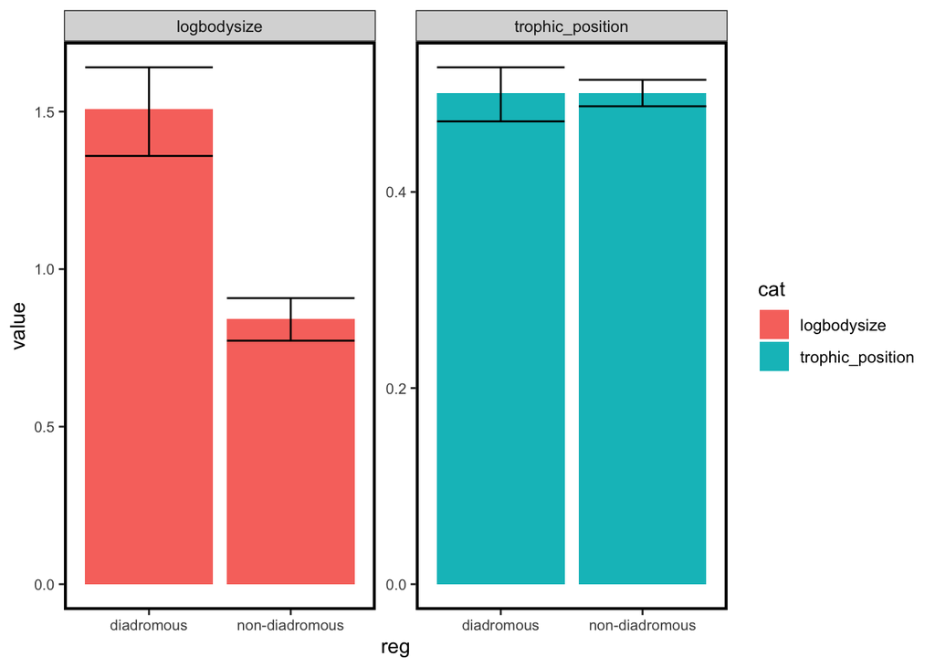

```r
plot1<-ggplot(data = Bloom_long_df, aes(x = reg, y = value, fill = cat)) +
  facet_wrap(~cat, nrow = 1, scales = "free") +
  stat_summary(fun = mean,geom = "bar") +
  stat_summary(fun.data = mean_cl_boot, geom = "errorbar",color = "black")+theme_bw()+
  theme(plot.title = element_text(size = 20, colour="black",face = "bold"),
        axis.text = element_text(size=8),
        panel.border = element_rect(size = 1.5, colour = "black"),
        panel.grid.major = element_blank(), panel.grid.minor = element_blank())
plot1
```

##### Plot2: Point and error bars (mean and 95% conf. int.)

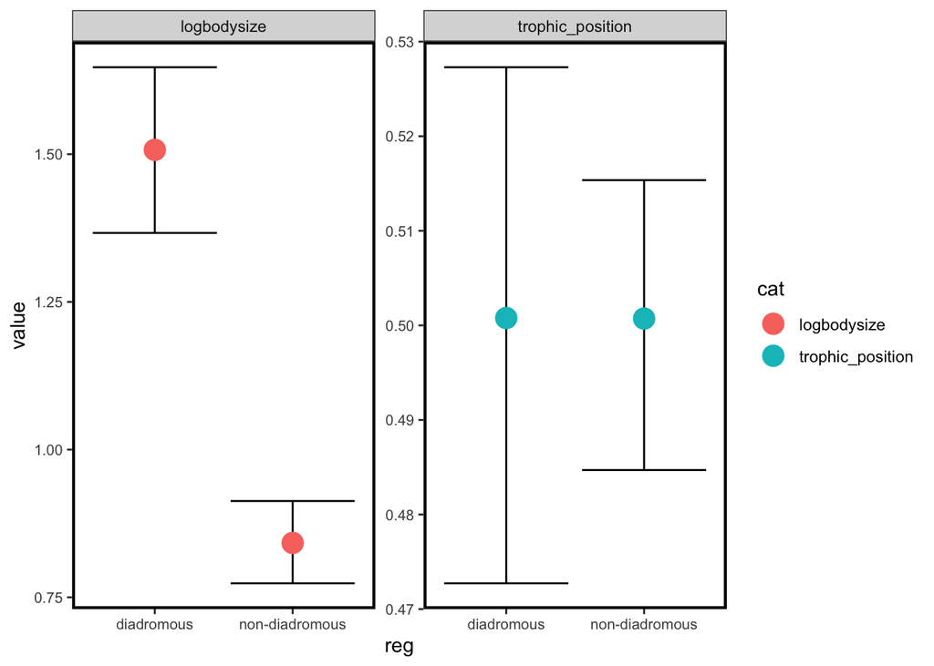

```r
plot2 <- ggplot(data = Bloom_long_df, aes(x = reg, y = value, colour = cat)) +
  facet_wrap(~cat, nrow = 1, scales = "free") +
  stat_summary(fun.data = mean_cl_boot,geom = "errorbar", color = "black") +
  stat_summary(fun = mean,geom = "point", size = 5)+theme_bw()+
  theme(plot.title = element_text(size = 20, colour="black",face = "bold"),axis.text = element_text(size=8),panel.border = element_rect(size = 1.5, colour = "black"),
        panel.grid.major = element_blank(), panel.grid.minor = element_blank())
plot2
```

##### Plot3: Box plots

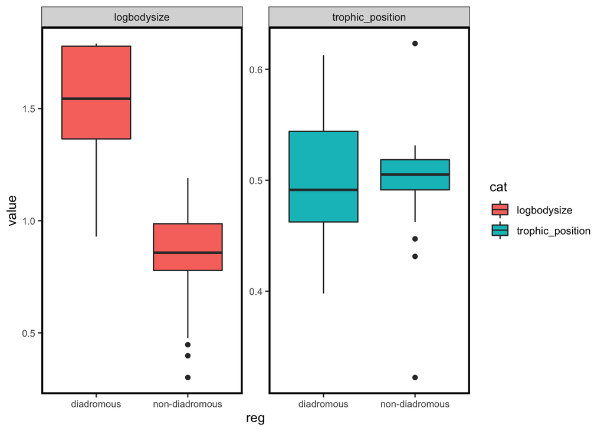

```r
plot3 <- ggplot(data = Bloom_long_df, aes(x = reg, y = value, fill = cat)) +
  facet_wrap(~cat, nrow = 1, scales = "free") + geom_boxplot()+theme_bw()+theme_bw()+
  theme(plot.title = element_text(size = 20, colour="black",face = "bold"),
        axis.text = element_text(size=8),
        panel.border = element_rect(size = 1.5, colour = "black"),
        panel.grid.major = element_blank(), panel.grid.minor = element_blank())
plot3
```

##### Plot4: Raw data + point and error bars (mean and 95% conf. int.)

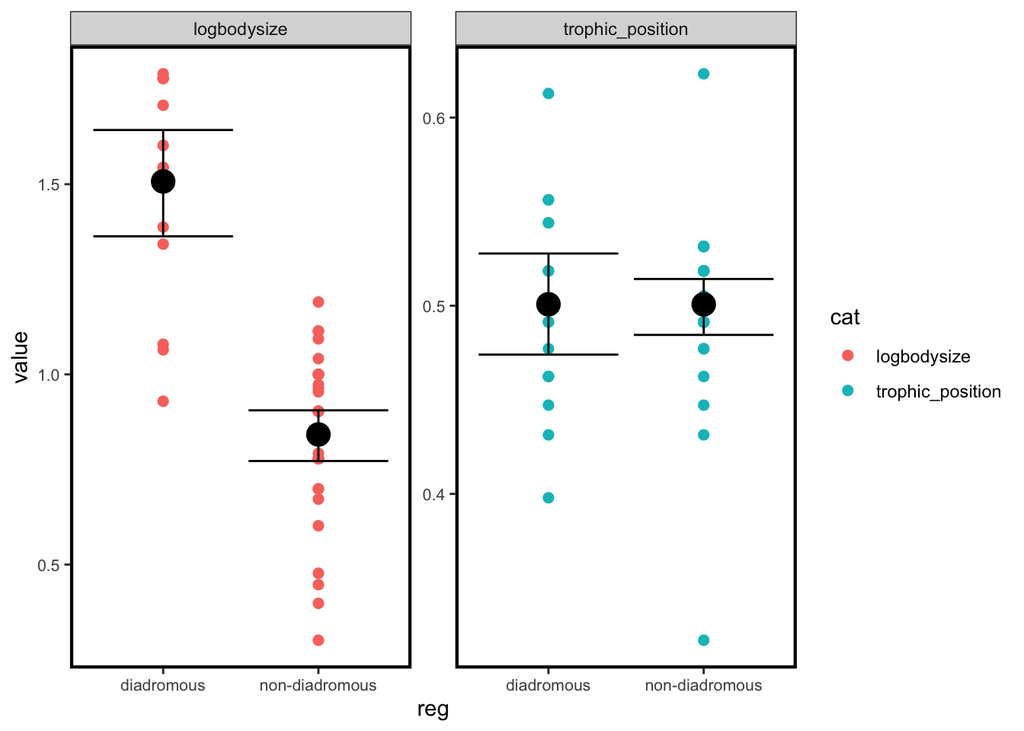

```r
plot4 <- ggplot(data = Bloom_long_df, aes(x = reg, y = value, colour = cat)) +
  facet_wrap(~cat, nrow = 1, scales = "free") + geom_point(size = 2) +
  stat_summary(fun.data = mean_cl_boot, geom = "errorbar",
               color = "black") + stat_summary(fun = mean, geom = "point",
                                               size = 5, colour = "black")+theme_bw()+
  theme(plot.title = element_text(size = 20, colour="black",face = "bold"),
        axis.text = element_text(size=8),
        panel.border = element_rect(size = 1.5, colour = "black"),
        panel.grid.major = element_blank(), panel.grid.minor = element_blank())
plot4
```

##### Merge these four images

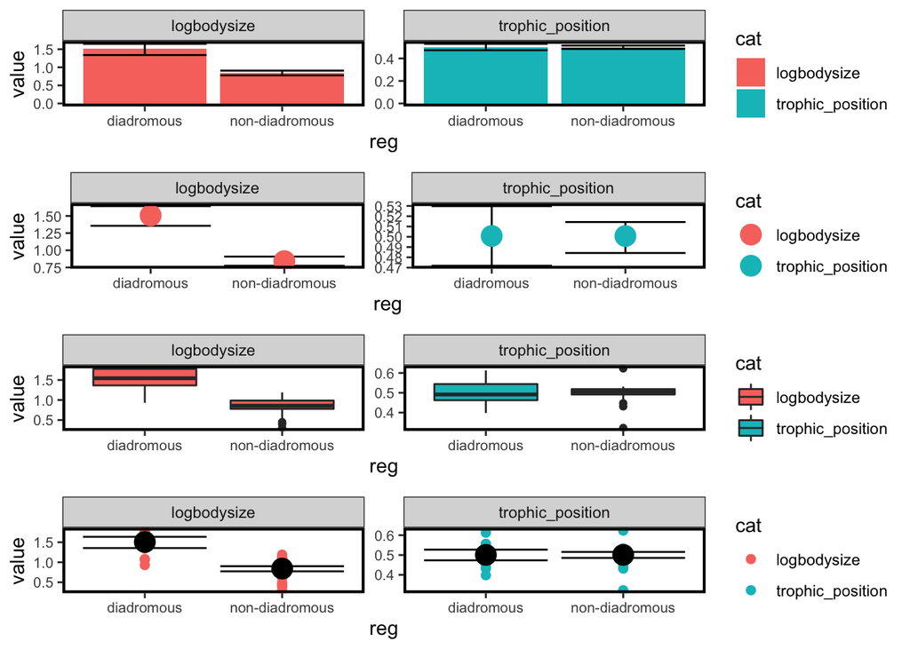

```r
ggarrange(plot1, plot2, plot3, plot4,ncol = 1,nrow = 4,hjust = -0.5,vjust = 1.5,
          font.label = list(size = 8, color = "black", face = "bold", family = NULL),
          align = c("none", "h", "v", "hv"),
          widths = 1,
          heights = 1,
          legend = NULL,
          common.legend = FALSE)
```

### Task 3: layering your plots

Make any two figures with the bloom_df! Can be something we’ve done or something completely different. Make one TERRIBLE figure and one GREAT figure.

Put them together using *patchwork* or *ggarrange*

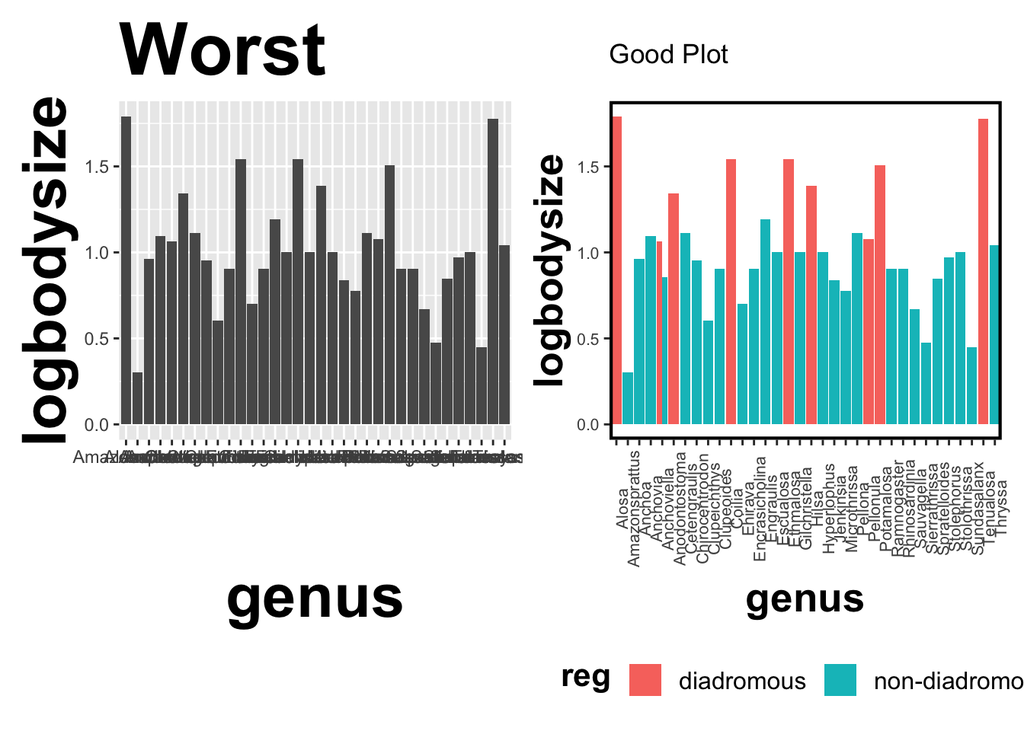

```r
Bad_plot <- ggplot(data = bloom_df, aes(x = genus, y = logbodysize)) + geom_bar(stat = "identity", position = "dodge") + ggtitle("Worst") +
  theme(title = element_text(size = 30,colour = "black", face = "bold"))

Good_plot <- ggplot(data = bloom_df, aes(x = genus, y = logbodysize,fill=reg)) + geom_bar(stat = "identity", position = "dodge") +
  theme_bw()+ ggtitle("Good Plot") +theme(legend.position = 'bottom', axis.text.x = element_text(angle=90),
        axis.text = element_text(size=8),
        axis.title = element_text(size = 20, colour="black",face = "bold"),
        panel.border = element_rect(size = 1.5, colour = "black"),
        legend.title = element_text(size = 16, colour="black",face = "bold",vjust = 1),
        legend.text = element_text(size=12),
        panel.grid.major = element_blank(), panel.grid.minor = element_blank())

Bad_plot + Good_plot
```

### Bonus: make a map (not required)

In the github for this course, there is an Rmarkdown called *ggmap_ex*. You can use this as a reference to make a map using any data you want. Try using your own data so it is useful.

```r
#bonus map
```